# Esports - evolution and present state

Ran K

24/10/2020

# 1 Introduction.

[figure not shown]

[Photo source](https://econreview.berkeley.edu/the-explosive-growth-of-esports/)

According to [Wikipedia](https://en.wikipedia.org/wiki/Esports) -  
Esports (also known as electronic sports, e-sports, or eSports) is a form of sport competition using video games. Esports often takes the form of organized, multiplayer video game competitions, particularly between professional players, individually or as teams.

- **In the notebook** I will try to shine some light on this growing industy by doing an **Exploratory data analysis** or **EDA**, then, I will try to visualise some of the effects of the recent pandemic on the industry.
- **This dataset** comes entirely from [EsportsEarnings.com](https://www.esportsearnings.com).  
  As the data in the site is collected by volunteers, it is likely that there would be some errors in documentation (I would assume these errors are more frequent in smaller tournaments and in tournaments that orgenised in the early 2000’s, when the Esports scene was a lot smaller). This means that we should take all the earnings data with a grain of salt and not as definitive.

## 1.1 Loading datasets and some variable manipulation

Loading our 2 datasets

```r
HistData <- read.csv("HistoricalEsportData.csv")

str(HistData)
```

```
## 'data.frame':    6215 obs. of  5 variables:
##  $ Date       : chr  "1/1/1998" "5/1/1998" "7/1/1998" "7/1/1998" ...
##  $ Game       : chr  "QuakeWorld" "Quake II" "Quake II" "QuakeWorld" ...
##  $ Earnings   : num  15000 14600 15000 6500 36600 22000 20000 2000 15000 3000 ...
##  $ Players    : int  8 4 5 4 13 0 8 1 5 2 ...
##  $ Tournaments: int  1 1 1 1 2 1 1 1 1 1 ...
```

```r
GenData <- read.csv("GeneralEsportData.csv")

str(GenData)
```

```
## 'data.frame':    503 obs. of  7 variables:
##  $ Game            : chr  "Age of Empires" "Age of Empires II" "Age of Empires III" "Age of Empires Online" ...
##  $ ReleaseDate     : int  1997 1999 2005 2011 2002 2018 2019 2018 2007 2014 ...
##  $ Genre           : chr  "Strategy" "Strategy" "Strategy" "Strategy" ...
##  $ TotalEarnings   : num  190076 1492490 68114 2668 52360 ...
##  $ OnlineEarnings  : num  33236 875160 26614 2668 360 ...
##  $ TotalPlayers    : int  246 956 106 16 22 5 72 51 614 60 ...
##  $ TotalTournaments: int  95 576 76 7 6 2 6 10 164 9 ...
```

Also, ill manipulate the **Date** variable into a date format, ill add a variable indicating the year and the month ill edit some of the genres to not be too long (which will interfere with plotting).

```r
options(scipen = 100)

# I would like to change the "Year" variable into date format
HistData$Date <- as.Date(HistData$Date, format = "%m/%d/%Y")

# Adding timely variables to facilitate plotting
HistData$Year <- as.numeric(regmatches(HistData$Date,regexpr("^\\d{4}",HistData$Date)))
HistData$Month <- as.numeric(regmatches(HistData$Date,regexpr("\\d{2}(?=-01$)",HistData$Date, perl = TRUE)))

GenData$Genre <- gsub(" Game","",GenData$Genre)
GenData$Genre[which(GenData$Genre == "Multiplayer Online Battle Arena")] <- "MOBA"
GenData$Genre[which(GenData$Genre == "Role-Playing")] <- "RPG"
GenData$Genre[which(GenData$Genre == "Third-Person Shooter")] <- "TPS"
GenData$Genre[which(GenData$Genre == "First-Person Shooter")] <- "FPS"


unique(GenData$Genre)
```

```
##  [1] "Strategy"         "FPS"              "MOBA"             "RPG"
##  [5] "Fighting"         "Racing"           "Sports"           "Collectible Card"
##  [9] "Puzzle"           "Battle Royale"    "TPS"
```

Much better

## 1.2 Removing games who “do not belong” in this database.

I have came to the conclusion that not every game presented in our database should be taked in consideration:  
We will filter out games who do not meet *earning* and *tournament* restrictions For example: games without any recorded cash prizes or an extremely low amount (in the low hundreds), the same goes for the number of tournaments, a game which held only a tournament or to should not be considered in my opinion.

I have decided to ommit from the database games who have either **less then 500$ in prize pool earnings** and game with **less then 5 tournaments and a total prize pool of under 2000$** recorded.

```r
Games_to_filter <- GenData$Game[which(GenData$TotalEarnings < 500 | (GenData$TotalTournaments < 5 & GenData$TotalEarnings <2000))]

GenData <- GenData[-which(GenData$Game %in% Games_to_filter),]
HistData <- HistData[-which(HistData$Game %in% Games_to_filter),]

rm(Games_to_filter) # No longer necessary
```

We are now ready to start our analysis.

# 2 Explanatory Data Analysis.

In this part, i’d like to explore the different variables and the possible relationship they have with each other in the hopes of getting some insight into the ins and out of this up and coming industry.

First of all, let’s look at which games had the biggest amount of money distributed.

## 2.1 Biggest Games (earning wise).

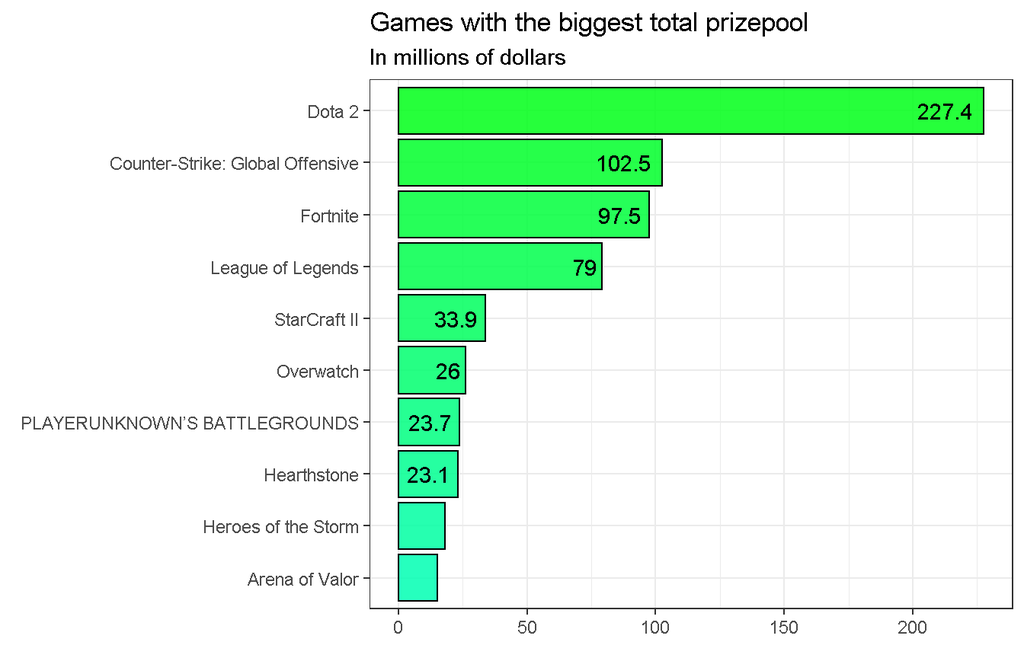

```r
# Plotting top earnings bar chart

GenData %>%
  arrange(desc(TotalEarnings)) %>%
  slice(1:10) %>%
  mutate(Game = fct_reorder(Game,TotalEarnings,.desc = FALSE)) %>%
  ggplot(aes(x = Game, y = TotalEarnings)) +
  geom_col(fill = rainbow(n = 10 , start = 0.35, end = 0.45), color = "black", alpha = 0.85) +
  coord_flip() +
  labs(x = element_blank(),y = element_blank(),
       title = "Games with the biggest total prizepool", subtitle = "In millions of dollars") +
  scale_y_continuous(labels = scales::label_number(scale = 1/1E6)) +
  geom_text(aes(label = ifelse(TotalEarnings >= 20E6,round(TotalEarnings/(1E6),1),"")), hjust = 1.2)
```

In the top 10 biggest games, there are no apparent surprises, we find **Dota 2**, **CS:GO**,**Fortnite**,**League of Legends**, and **Starcraft 2** at the top.

Let’s see the evolution of prizes destributed in these top 5 games.

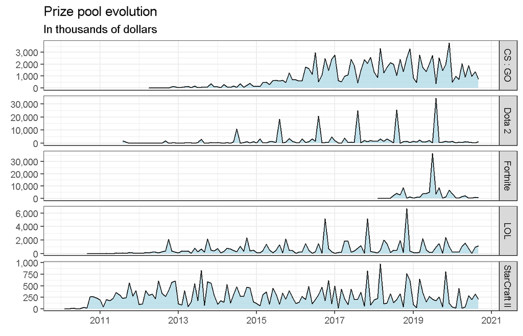

```r
# It is possible to use an internal pipe operation -> amazing for wrangling data for plots.

HistData %>%
  filter(Game %in% c(GenData[order(-GenData$TotalEarnings),1] %>%
                       head(5))) %>%
  mutate(Game = if_else(Game == "Counter-Strike: Global Offensive","CS : GO",
                        if_else(Game == "League of Legends","LOL",Game))) %>%
  ggplot(aes(x = Date, y = Earnings)) +
  geom_area(fill = "lightblue",color = "black",alpha = 0.75) +
  facet_grid(Game ~ .,scales = "free") +
  labs(title = "Prize pool evolution",subtitle = "In thousands of dollars",
       x = element_blank(), y = element_blank()) +
  scale_x_date(breaks = "2 years", date_labels = "%Y") +
  scale_y_continuous(labels = label_comma(scale = 1/1000))
```

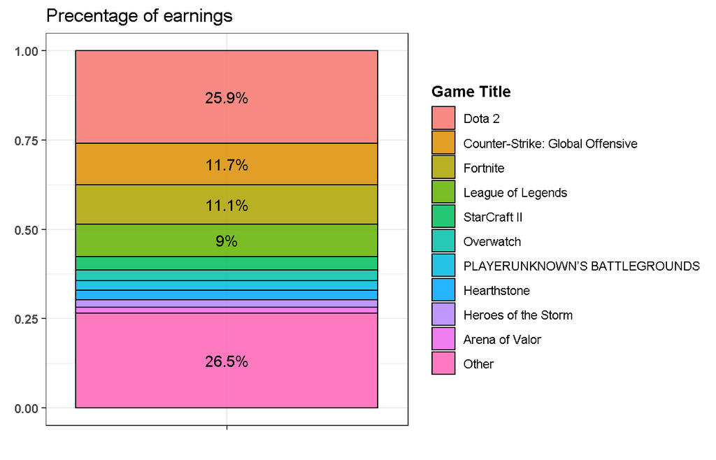

```r
# In order to create this plot, I condensed the database into 11 obeservarions, then created the variable used in the plot, then did two action of level reordering in order to achieve the custom ordering.

GenData %>%
  mutate(Game = fct_lump_n(f = Game,n = 10,w = TotalEarnings,other_level = "Other")) %>%
  group_by(Game) %>%
  summarise(Earnings = sum(TotalEarnings)) %>%
  mutate(Proportion = Earnings/sum(Earnings),
  Game = fct_reorder(.f = Game, .x = Proportion,.fun = max, .desc = TRUE),
  Game = fct_relevel(.f = Game, "Other", after = Inf)) %>%
  ggplot(aes(x = "",y = Proportion,fill = Game)) +
  geom_col(width = 1,color = "black",alpha = 0.85) +
  theme(legend.position = "right", legend.title = element_text(face = "bold"),
        axis.text = element_text(face = "bold")) +
  labs(title = "Precentage of earnings", y = element_blank(), x = element_blank(),
       fill = "Game Title") +
  geom_text(aes(label = ifelse(Proportion >0.08,paste0(round(Proportion,3)*100,"%"),"")),position = position_stack(vjust = 0.5))
```

We can see that the earnings are highly concentrated: almost 50% of the earnings are concentrated in 3 games and about 75% of the total earnings come from the biggest 10 games. Also, it is quite shocking that about a quarter of all prize pool earnings have came solely from **Dota 2** tournaments.

Now let’s see which games held the highest amount of tournaments.

## 2.2 Biggest Games (tournament wise).

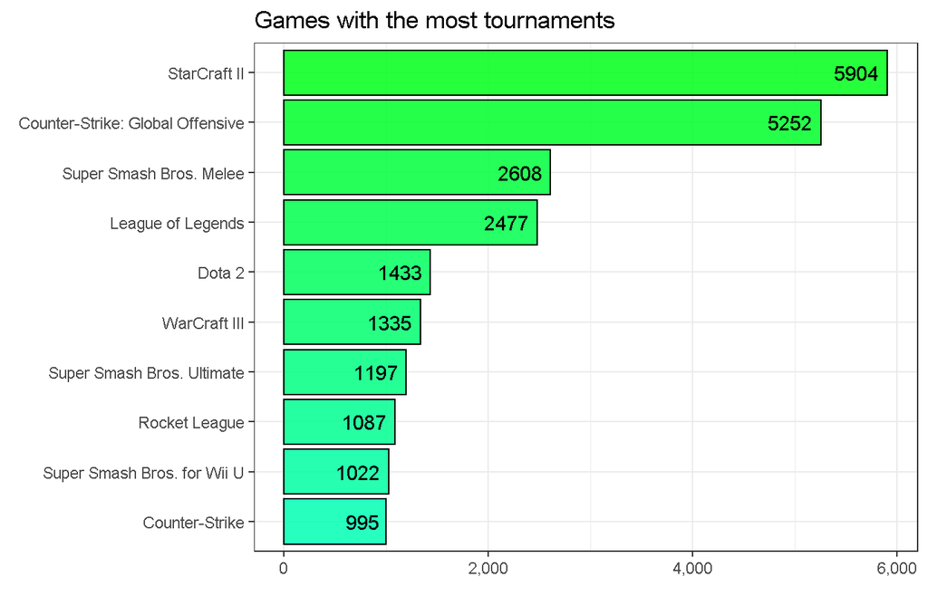

```r
# Plotting

GenData %>%
  arrange(desc(TotalTournaments)) %>%
  slice(1:10) %>%
  mutate(Game = fct_reorder(Game,TotalTournaments,.desc = FALSE)) %>%
  ggplot(aes(x = Game, y = TotalTournaments)) +
  geom_col(fill = rainbow(n = 10 , start = 0.35, end = 0.45), color = "black", alpha = 0.85) +
  coord_flip() +
  labs(title = "Games with the most tournaments",x = element_blank(), y = element_blank()) +
  scale_y_continuous(labels = scales::label_comma()) +
  geom_text(aes(label = TotalTournaments), hjust = 1.2)
```

It is not surprising that we find a similarity between the two lists: Dota 2, Starcraft 2, League of Legends and Counter-Strike: Global Offensive are all in the top 10 in prizepool earnings.  
What is somewhat interaesting is the fact that we have 3 different Super Smash Bros games, all in the top 10, this is while being not as big in the matter of prize pools (1.2M, 1.5M and 3.1M).

Let’s see the evolution of the amount of tournaments which were being held for the top 5 games.

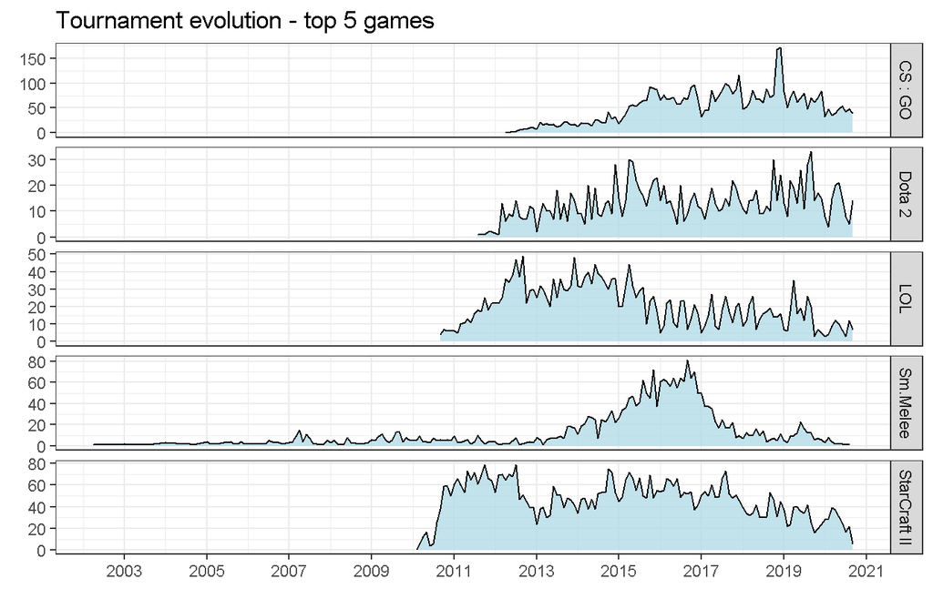

```r
HistData %>%
  filter(Game %in% c(GenData[order(-GenData$TotalTournaments),1] %>%
                       head(5))) %>%
  mutate(Game = if_else(Game == "Counter-Strike: Global Offensive","CS : GO",
                        if_else(Game == "League of Legends","LOL",
                                if_else(Game == "Super Smash Bros. Melee","Sm.Melee",Game)))) %>%
  ggplot(aes(x = Date, y = Tournaments)) +
  geom_area(fill = "lightblue",color = "black",alpha = 0.75) +
  facet_grid(Game ~ .,scales = "free") +
  labs(title = "Tournament evolution - top 5 games",x = element_blank(), y = element_blank()) +
  scale_x_date(breaks = "2 years", date_labels = "%Y") +
  scale_y_continuous(labels = label_comma())
```

The distribution of **Dota** and **LOL** tournaments seems cyclical, also, it is interesting how there where **Super Smash Bros.Melee** tournamnets back in 2003 but the amount picked up only around 2014.

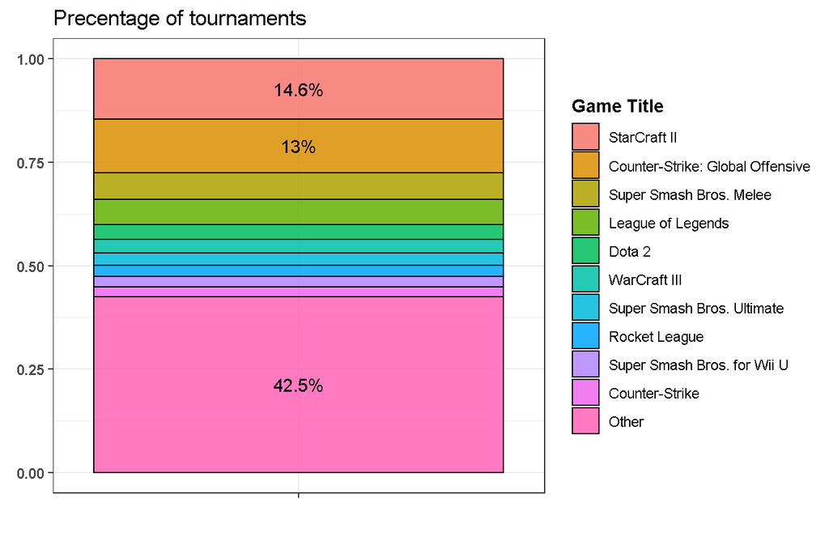

```r
# Plotting
GenData %>%
  mutate(Game = fct_lump_n(f = Game,n = 10,w = TotalTournaments,other_level = "Other")) %>%
  group_by(Game) %>%
  summarise(Tournaments = sum(TotalTournaments)) %>%
  mutate(Proportion = Tournaments/sum(Tournaments),
  Game = fct_reorder(.f = Game, .x = Proportion,.fun = max, .desc = TRUE),
  Game = fct_relevel(.f = Game, "Other", after = Inf)) %>%
  ggplot(aes(x = "",y = Proportion,fill = Game)) +
  geom_col(width = 1,color = "black",alpha = 0.85) +
  theme(legend.position = "right", legend.title = element_text(face = "bold"),
        axis.text = element_text(face = "bold")) +
  labs(title = "Precentage of tournaments", y = element_blank(), x = element_blank(),
       fill = "Game Title") +
  geom_text(aes(label = ifelse(Proportion >0.08,paste0(round(Proportion,3)*100,"%"),"")),position = position_stack(vjust = 0.5))
```

Indeed, tournaments are a little less concentrated then earnings.

## 2.3 A yearly look at earnings and tournaments.

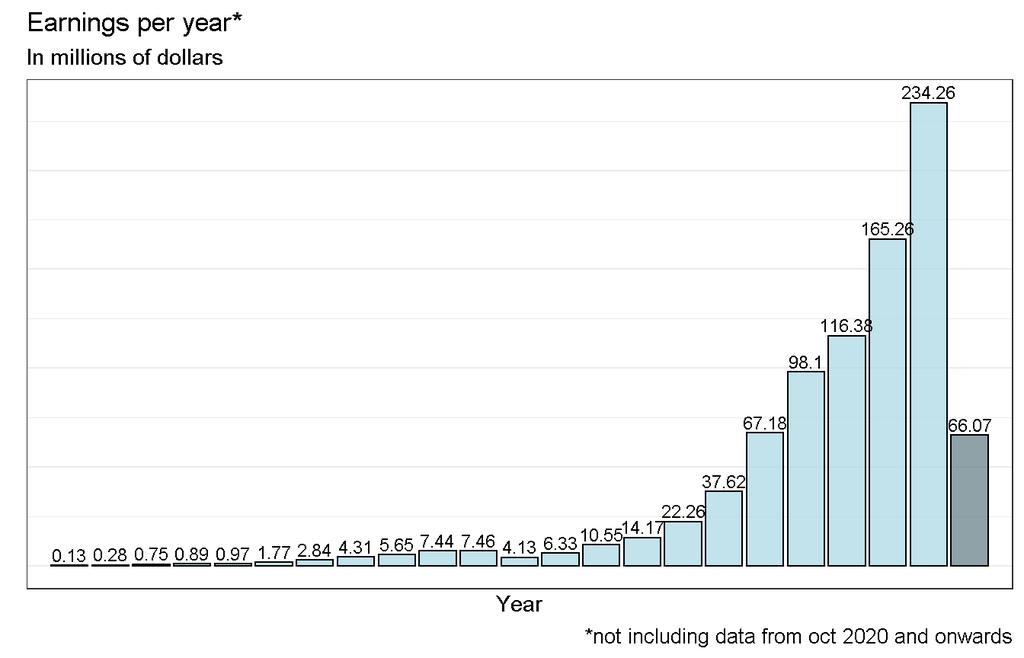

```r
# Plotting Earnings per year
HistData %>%
         group_by(Year) %>%
         summarise(TotalEarnings = sum(Earnings)) %>%
         mutate(Condition = ifelse(Year == 2020,TRUE,FALSE)) %>%
 ggplot(aes(x = Year, y = TotalEarnings, fill = Condition)) +
  geom_bar(stat = "Identity",color = "black",alpha = 0.75) +
  geom_text(aes(label = round(TotalEarnings/1E6,2)), vjust = -0.3, size = 3) +
  theme(axis.text.y = element_blank(), axis.ticks.y = element_blank(),
        plot.caption = element_text(size = 10)) +
  scale_x_discrete(labels = c(98,99,seq(00,20,1))) +
  labs(title = "Earnings per year*", subtitle = "In millions of dollars", caption = "*not including data from oct 2020 and onwards", y = element_blank(),x = "Year") +
  scale_fill_manual(values = c("lightblue","lightblue4")) +
  guides(fill = "none")
```

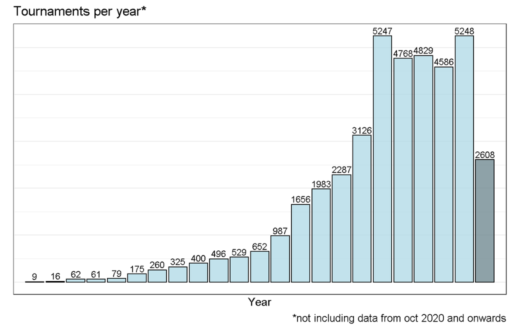

```r
# Plotting Tournaments per year

HistData %>%
         group_by(Year) %>%
         summarise(TotalTournaments = sum(Tournaments)) %>%
         mutate(Condition = ifelse(Year == 2020,TRUE,FALSE)) %>%
 ggplot(aes(x = Year, y = TotalTournaments, fill = Condition)) +
  geom_bar(stat = "Identity",color = "black",alpha = 0.75) +
  geom_text(aes(label = TotalTournaments), vjust = -0.3, size = 3) +
  theme(axis.text.y = element_blank(), axis.ticks.y = element_blank(),
        plot.caption = element_text(size = 10)) +
  scale_x_discrete(labels = c(98,99,seq(00,20,1))) +
  labs(title = "Tournaments per year*", y = element_blank(),x = "Year",
       caption = "*not including data from oct 2020 and onwards") +
  scale_fill_manual(values = c("lightblue","lightblue4")) +
  guides(fill = "none")
```

Tournament wise, we see that the number of tournaments started to skyrocket in 2011, stabilizing at the 4500 - 5500 range from 2015 onwards.

Now let’s look at the monthly data: is there a specific period where there are more tournaments and more prize earnings?

## 2.4 A monthly look at earnings and tournaments.

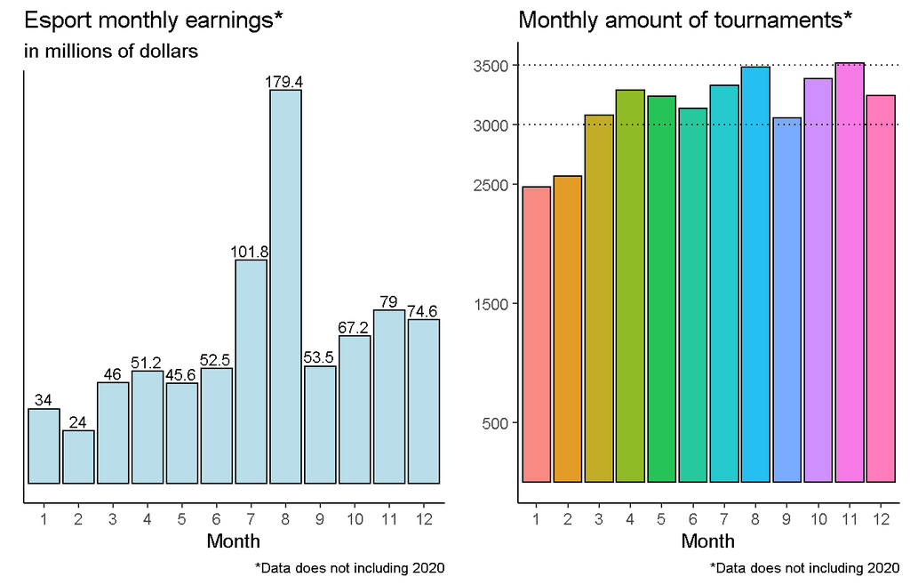

```r
# For the purpose of this plot ill transform the month variable into a factor
HistData$Month <- as.factor(HistData$Month)

# Plotting
p1 <- ggplot(data = HistData %>%
         filter(Date < "2020-01-01") %>%
         group_by(Month) %>%
         summarise(Earnings_in_millions = round(sum(Earnings)/10^6,1)),
         aes(x = Month, y = Earnings_in_millions)) +
  theme_classic() +
  geom_bar(stat = "identity",fill = "lightblue",color = "black",alpha = 0.85) +
  theme(legend.position='none', plot.caption = element_text(size = 8)) +
  geom_text(aes(label = Earnings_in_millions), vjust = -0.3,hjust = 0.55, size = 3) +
  labs(title = "Esport monthly earnings*", subtitle = "in millions of dollars",
       y = element_blank(), caption = "*Data does not including 2020") +
  theme(axis.text.y = element_blank(), axis.ticks.y = element_blank())

p2 <- ggplot(data = HistData %>%
         filter(Date < "2020-01-01") %>%
         group_by(Month) %>%
         summarise(Tournaments = sum(Tournaments)), aes(x = Month, y = Tournaments,fill = Month)) +
  geom_bar(stat = "identity", color = "black",alpha = 0.85) +
  theme_classic() +
  theme(legend.position='none', plot.caption = element_text(size = 8)) +
  labs(title = "Monthly amount of tournaments*", y = element_blank(),
       caption = "*Data does not including 2020") +
  geom_hline(yintercept = 3000,linetype = "dotted") +
  geom_hline(yintercept = 3500,linetype = "dotted") +
  scale_y_continuous(breaks = c(500,1500,2500,3000,3500))

grid.arrange(p1,p2,ncol = 2)
```

```r
rm(list = c("p1","p2"))
```

## 2.5 Which games have distributed cash prizes for the most players.

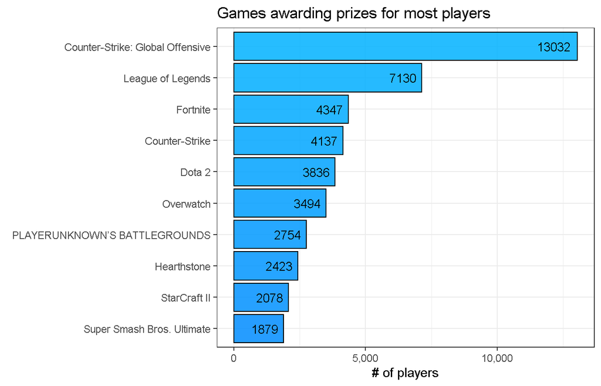

```r
# Plotting

GenData[order(GenData$TotalPlayers, decreasing = TRUE),] %>%
  slice(1:10) %>%
  ggplot(aes(x = reorder(Game,+ TotalPlayers), y = TotalPlayers)) +
  geom_bar(stat = "identity",
           fill = rainbow(n = 10 , start = .55, end = 0.575), color = "black", alpha = 0.85) +
  coord_flip() +
  labs(x = element_blank(), y = "# of players",title = "Games awarding prizes for most players") +
  scale_y_continuous(labels = scales::comma) +
  geom_text(aes(label = TotalPlayers, hjust = 1.2),size = 3.5)
```

It is interesting to note that in this list, most games are either played in teams of 5 or are a part of the **Battle Royal** genre in which each match could hold up to 100 players. however, 2 games stand out, **Hearthstone** , **StarCraft II** (in positions 8, 9): These games are exclusively 1v1 based (there is an option for 2v2 in starcraft, however there are not compatitive compatitions for this mode).

Now let’s look at the diffrenet genres

## 2.6 A look at Genres

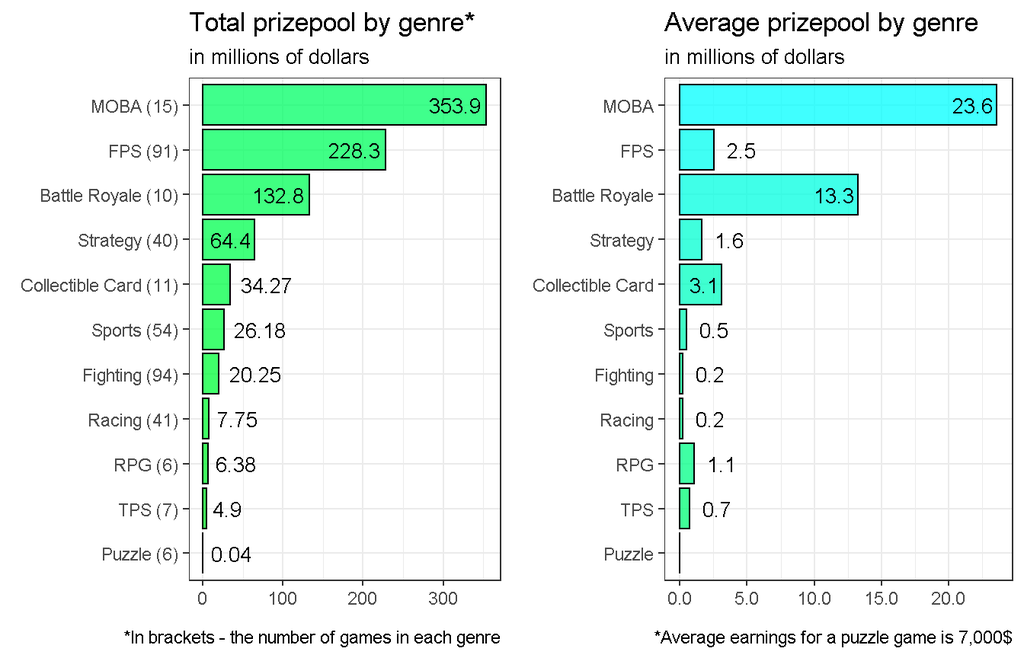

```r
# Plotting total earnings per genre
p3 <- GenData %>%
  group_by(Genre) %>%
  summarise(TotalEarnings = sum(TotalEarnings),
                   AverageErnings = mean(TotalEarnings),
                   Number = n()) %>%
  mutate(Genre = glue("{Genre } ({Number})"),
  Genre = fct_reorder(Genre,TotalEarnings)) %>%
  arrange(TotalEarnings) %>%
ggplot(aes(x = Genre,y = TotalEarnings)) +
  geom_col(alpha = 0.75,color = "black",
           fill = rainbow(n = 11 , start = .35, end = .40)) +
  coord_flip() +
  theme(legend.position = "none",plot.subtitle = element_text(size = 10)) +
  labs(title = "Total prizepool by genre*",
       subtitle = "in millions of dollars",caption ="*In brackets - the number of games in each genre",
       y = element_blank(), x = element_blank(), fill = "") +
  geom_text(aes(label = ifelse(TotalEarnings >60E6,round(TotalEarnings/1E6,1),round(TotalEarnings/1E6,2))
                ,hjust = if_else(TotalEarnings > 60E6,1.1,-0.2)),
             size = 3.5) +
  scale_y_continuous(label = label_number(scale = 1/1E6))

p4 <- GenData %>%
  group_by(Genre) %>%
  summarise(TotalEarnings = sum(TotalEarnings),
                   AverageErnings = sum(TotalEarnings)/n(),
                   Number = n()) %>%
  mutate(Genre = fct_reorder(Genre,TotalEarnings)) %>%
  arrange(TotalEarnings) %>%
ggplot(aes(x = Genre,y = AverageErnings)) +
  geom_col(alpha = 0.75,color = "black",fill = rainbow(n = 11 , start = .40, end = .50)) +
  coord_flip() +
  theme(legend.position = "none",plot.subtitle = element_text(size = 10)) +
  labs(title = "Average prizepool by genre",
       subtitle = "in millions of dollars",caption ="*Average earnings for a puzzle game is 7,000$",
       y = element_blank(), x = element_blank(), fill = "") +
  geom_text(aes(label = ifelse(AverageErnings > 1E5,round(AverageErnings/1E6,1),""),hjust = if_else(AverageErnings > 3E6,1.1,-0.45)),
             size = 3.5) +
  scale_y_continuous(label = label_number(scale = 1/1E6))

grid.arrange(p3,p4,ncol = 2)
```

```r
rm(list = c("p3","p4"))
```

- As expected, the **MOBA** genre is largly on top of the earning leaderboard, it is followed by the **First-person shooter** genre and by the quite new **Battle Royale** genre.
- We see that games in the **MOBA** and **Battle Royale** genres are a lot more successful in relation to other genres, this makes since as the games in these are designed to be esport compatible.

Regarding the number of games in each genre.  
It is no surprise that we find **FPS**, **Fighting**, **Racing** and **Sports** are the genres with the most games, it is due to the fact that there are more franchises in these genres, and every franchise has new games being released quite often (the **Call of Duty** and **Fifa** franchises come to mind).  
However, I find it interesting to see so many **Strategy** games, as there less franchises in this genre, and it seemed to me that the strategy genre is in the process of slowly dying down.

To check this, ill create a plot with these 5 genres to see what percentages of games came out in the last couple of years.

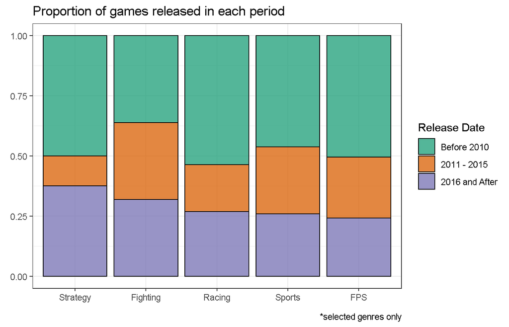

```r
GenData %>%
         filter(Genre %in% c("FPS","Racing","Fighting","Strategy","Sports")) %>%
         mutate(ReleaseGroup = ifelse(ReleaseDate <= 2010,"Before 2010", ifelse(ReleaseDate <= 2015,"2011 - 2015","2016 and After"))) %>%
  ggplot(aes(x = factor(Genre,levels = c("Strategy","Fighting","Racing","Sports","FPS")),
           fill = factor(ReleaseGroup,levels = c("Before 2010","2011 - 2015","2016 and After")))) +
  geom_bar(position = "fill",color = "black",alpha = 0.75) +
  labs(fill = "Release Date", x = element_blank(), y = element_blank()) +
  scale_fill_brewer(palette = "Dark2") +
  labs(title = "Proportion of games released in each period", caption = "*selected genres only")
```

Looking at the bar chart we can conclude that our assumption that the **Strategy** genre is dying down is quite false, as there is a significant proportion of games the came out in the last few year.

Now let’s look at the release date, how many games are released in each year and do games from a specific year have a biggest impact on the Esports industry?

## 2.7 A look at release dates.

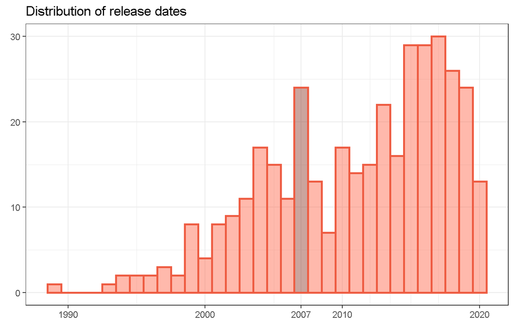

```r
# Plotting
ggplot(data = GenData %>% mutate(Temp = ifelse(ReleaseDate == 2007,TRUE,FALSE)), aes(x = ReleaseDate,fill = Temp)) +
  geom_histogram(color = "tomato2",alpha = 0.45,size = 1,binwidth = 1) +
  labs(title = "Distribution of release dates", y = element_blank(), x = element_blank()) +
  scale_x_continuous(breaks = c(seq(from = 1990, to = 2200, by = 10),2007)) +
  scale_fill_manual(values = c("tomato1","tomato4")) +
  guides(fill = "none")
```

It is intersting to note that there after 2007 there was a sharp decrease in the amount of releases - I would suspect that it is due to the 2008 financial crisis.

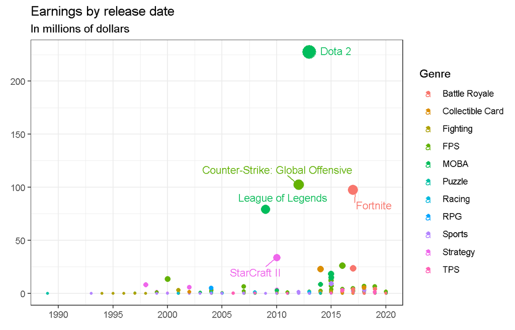

```r
# Plotting
ggplot(data = GenData, aes(x = ReleaseDate,y = TotalEarnings,color = Genre,size = TotalEarnings)) +
  geom_point() +
  ggrepel::geom_text_repel(data = head(GenData[order(-GenData$TotalEarnings),],5),
               aes(label = Game), size = 3.5,
               box.padding = unit(0.45, "lines"),
               point.padding = unit(0.3, "lines")) +
  guides(size = "none") +
  scale_y_continuous(labels = scales::label_number(scale = 1/1000000)) +
  scale_x_continuous(breaks = seq(from = 1980, to = 2020, by = 5)) +
  labs(title = "Earnings by release date",subtitle = "In millions of dollars",
    y = element_blank(), x = element_blank())
```

It seems that there is no real connection between the release date of a game and the success it has in the Esports scene.

# 3 Visualising the effect of the covid-19 pandemic.

As we all know, 2020 was a special not an ordinary year as the coronavirus pandemic has and is distrupting many industries, with the Esport industry being one of them.  
To try to visualise the effect by create a line chart showing monthly earnings and monthly amounts of tournaments in the past 5 years.  
If the pandemic had no effect, we should see that 2020 looks to be similar to prior years.

## 3.1 Effect on earnings.

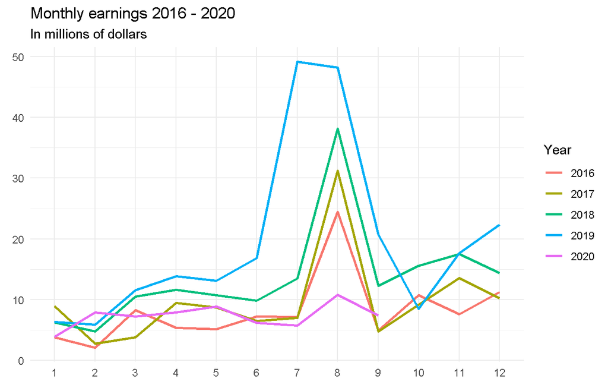

```r
# Filtering to last 5 years and plotting monthly earnings
HistData %>%
  filter(Date >= "2016-01-01") %>%
  group_by(Year,Month) %>%
  summarise(Earnings = round(sum(Earnings)/10^6,2)) %>%
  ungroup() %>%
  mutate(Year = as.factor(Year)) %>%
  ggplot(aes(x = Month, y = Earnings, group = Year)) +
  geom_line(aes(color = Year), size = 1) +
  theme_minimal() +
  labs(title = "Monthly earnings 2016 - 2020",
       subtitle = "In millions of dollars",x = element_blank(), y = element_blank())
```

As july and august are so important, let’s zoom in on this period.

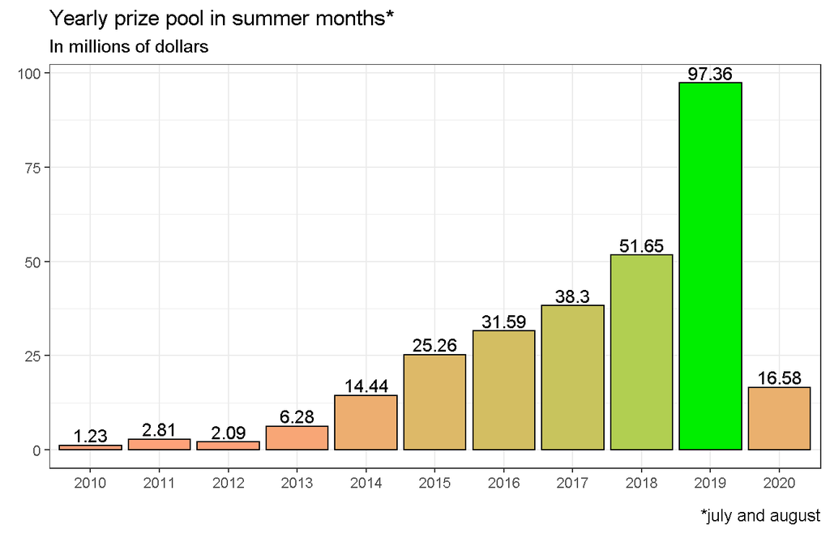

```r
# Filtering to last 5 years and plotting monthly earnings
HistData %>%
  filter((Month == 7 | Month == 8) ,Date >= "2010-01-01") %>%
  group_by(Year) %>%
  summarise(Earnings = round(sum(Earnings)/1E6,2)) %>%
  ggplot(aes(x = factor(Year), y = Earnings,fill = Earnings)) +
  geom_col(color = "black") +
  scale_fill_gradient(low ="lightsalmon",high = "green2") +
  labs(title = "Yearly prize pool in summer months*",
       subtitle = "In millions of dollars",caption = "*july and august",
       x = element_blank(), y = element_blank()) +
  guides(fill = "none") +
  geom_text(aes(label = Earnings, vjust = -0.25)) +
  theme(plot.caption = element_text(size = 10))
```

In the summer of 2020 the prizepool allocated in Esport tournements was **5 times** lower then in 2019. **Important note -** about half of the difference between 2020 and 2019 is due to the fact that the annual **Dota 2** tournament - “The International”, usually being held in august, had been postponed. The tournament should have had a prize pool of around 40 million dollars.  
Even if we taken this in considaration, the difference is still quite drastic.

Let’s look at the tournament plot now.

## 3.2 Effect on tournaments.

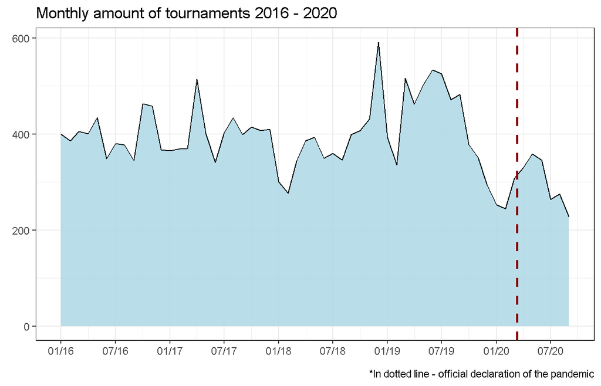

```r
# Filtering to last 5 years and plotting monthly amount of tournaments
HistData %>%
  filter(Date >= "2016-01-01") %>%
  group_by(Date) %>%
  summarise(Tournaments = sum(Tournaments)) %>%
  ggplot(aes(x = Date, y = Tournaments)) +
  geom_area(fill = "lightblue", alpha = 0.85) +
  geom_line(color = "black") +
  labs(title = "Monthly amount of tournaments 2016 - 2020",x = element_blank(), y = element_blank(),
       caption = "*In dotted line - official declaration of the pandemic") +
  scale_x_date(labels = date_format("%m/%y"),
               breaks = seq.Date(from = as.Date("2016-01-01"), to = as.Date("2021-01-01"), by ="6 months")) +
  geom_vline(xintercept = as.Date("2020-03-11"), linetype = "dashed", color = "darkred",size = 1)
```

It seems that tournements have been hit hard as well: after a usual weak start (as january and fabruary are the months with the lowest amounts of tournaments) the the number of tournaments did not rise as sharply as in recent years.

# 4 Conclusions.

We have learn a few things about the Esport industry

1. Prize money is extremely concentrated between a few games, this is less of the case in the amount of tournaments.
2. **Dota 2** is the game with the most earnings, **StarCraft II** the one with the most tournaments to date.
3. The summer (july - august) is the period with the most earning in the year, the winter (january - february) is the weakest period.
4. Tournament wise, january and february are the months with the lowest amount of tournaments, the rest of the year is stable.
5. The industry is mostly dominated by the **MOBA** and **Battle Royale** genres
6. There is not a clear relationship between the release date of a game and the success it will have in the Esport scene.
7. The coronavirus pandemic has hit hard the Esport scence, the effect could be seen in earnings and amounts of tournaments from the month march to present times, and there are no doubts that the industry will be affected for a longer period.
8. Finally, it is clear that the esport industry is on the rise, and it will be interesting to see how it will develop in the next couple of years.

### Thank you for reading, feel free to upvote or to leave a feedback

[figure not shown]